# Breast cancer prescribing

The following document sets out the observed and expected usage of the breast cancer medicines abemaciclib and neratinib. These medicines were selected as we have access to both primary and secondary care prescribing data and they are largely prescribed for an identifiable cohort of patients where we can estimate expected usage.

# Abemaciclib

## Relevant guidance

Abemaciclib, sold under the brand name Verzenios, was first recommended as a treatment for breast cancer in 2019, following publication of a NICE Technology appraisal (TA563). Since then, we have published two further Technology appraisals recommending abemiciclib for additional breast cancer indications. Details of currently published technology appraisals are included in the table below.

| Title | Reference number | Published |
| --- | --- | --- |
| Abemaciclib with endocrine therapy for adjuvant treatment of hormone receptor-positive, HER2-negative, node-positive early breast cancer at high risk of recurrence | TA810 | 20-Jul-22 |
| Abemaciclib with fulvestrant for treating hormone receptor-positive, HER2-negative advanced breast cancer after endocrine therapy | TA725 | 15-Sep-21 |
| Abemaciclib with an aromatase inhibitor for previously untreated, hormone receptor-positive, HER2-negative, locally advanced or metastatic breast cancer | TA563 | 27-Feb-19 |

## Therapeutic indications

### Early Breast Cancer

Abemiciclib in combination with endocrine therapy is indicated for the adjuvant treatment of adult patients with hormone receptor (HR)-positive, human epidermal growth factor receptor 2 (HER2)-negative, node-positive early breast cancer at high risk of recurrence.

In pre- or perimenopausal women, aromatase inhibitor endocrine therapy should be combined with a luteinising hormone-releasing hormone (LHRH) agonist.

### Advanced or Metastatic Breast Cancer

Abemiciclib is indicated for the treatment of women with hormone receptor (HR)-positive, human epidermal growth factor receptor 2 (HER2)-negative locally advanced or metastatic breast cancer in combination with an aromatase inhibitor or fulvestrant as initial endocrine-based therapy, or in women who have received prior endocrine therapy. In pre- or perimenopausal women, the endocrine therapy should be combined with a LHRH agonist.

## Eligible population

Around 4,000 people are expected to receive treatment with abemaciclib in England annually.

This has been taken from the Resource impact template developed for the NICE technology appraisal ‘Abemaciclib with endocrine therapy for adjuvant treatment of hormone receptor-positive, HER2-negative, node-positive early breast cancer at high risk of recurrence’, published July 2022.

| Eligible population | Number of people |
| --- | --- |
| Adult population | 44456850 |
| Adult population forecast at 2026/27 | 46263200 |
| Incidence of breast cancer | 50349 |
| Proportion of people with early or locally advanced disease | 43854 |
| Proportion of people with hormone receptor positive, HER2 negative disease | 28286 |
| Proportion of people with high-risk disease | 7071 |
| Eligible population at high risk of recurrence | 4059 |

## Observed usage

The table below is taken from data in the April 2022 publication of the innovation scorecard. It shows secondary care prescribing data by quarter in England for abemaciclib, also includes the very small amount of primary care data observed in the period.

| Medicine | FY Quarter | ADD | People (calculated) |
| --- | --- | --- | --- |
| Abemaciclib | 2017/18 Q4 | 180 | 2 |
| Abemaciclib | 2018/19 Q1 | 300 | 3 |
| Abemaciclib | 2018/19 Q2 | 210 | 2 |
| Abemaciclib | 2018/19 Q3 | 1140 | 13 |
| Abemaciclib | 2018/19 Q4 | 7642 | 84 |
| Abemaciclib | 2019/20 Q1 | 25984 | 286 |
| Abemaciclib | 2019/20 Q2 | 53583 | 589 |
| Abemaciclib | 2019/20 Q3 | 75136 | 826 |
| Abemaciclib | 2019/20 Q4 | 77941 | 856 |
| Abemaciclib | 2020/21 Q1 | 72652 | 798 |

[output cut: 6 more lines]

The observed usage of abemaciclib has increased since it was first authorized in 2018. In 2021 it was approaching the estimated expected level of prescribing.

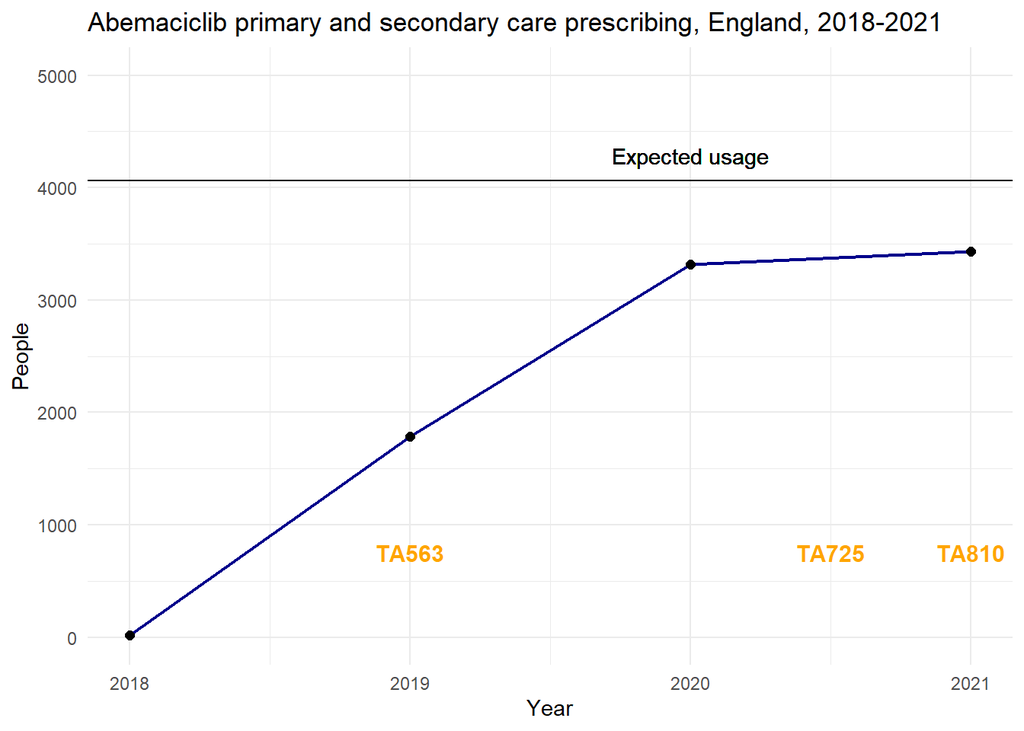